# holidays_any_new

This notebook shows examples of how public holiday features affect model predictions. Additionally, it provides prediction explanations in the form of shapley values. Here we examine 3 models:

- a baseline model that has date, sales aggregates, and pv features
- a model with date, sales aggregates, pv features, and public holidays (original or old)
- a model with date, sales aggregates, pv features, and public holidays (new encoded features)

We examine 5 holidays in 2019:

- Christmas
- Easter
- Christy Himmelfahrt
- National Tag
- Pfingsten

For this example analysis we only took 4 items 200063, 200036, 200031, and 200066

The presentation of analiysis always sticks to the same pattern

- present 2 charts with sales in 2018 and 2019
- 2 tables with uplift figures on 2018 and 2019
- 2 shapley value charts with prediction explanations of the model with original public holiday features. First one explains prediction on a day right before the holiday and the second one right after the holiday
- 2 shapley value charts with prediction explanations of the model with new public holiday features. First one explains prediction on a day right before the holiday and the second one right after the holiday
- 3 RMSE values for the baseline, baseline + orig. public holidays, baseline + new public holidays
- 4 charts: baseline prediction and actual sales, baseline + orig. holidays and actual sales, baseline + new public holidays and actual sales, everything in one

# Item number 200066

```python
import altair as alt
import pandas as pd
import numpy as np
import pickle5 as pickle
```

```python
#item_nr = 200048  #ok but not all holidays
#threshold = 5000

#item_nr = 208450
#threshold = 500

#item_nr = 200063 # good example
#threshold = 500

#item_nr = 200031 # good example
#threshold = 200

#item_nr = 200036 # good example
#threshold = 200

#item_nr = 200032
#threshold = 200

#item_nr = 218685 # so so
#threshold = 200

#item_nr = 200050 # pv occurred around all holidays
#threshold = 200

item_nr = 200066 # good example
threshold = 200
```

Read the data generated by the code in branch feature/holiday_analysis_evaluation.

```python
filename = '/Users/sharapov/Desktop/pub_hol/results_with_base_at_' + str(item_nr)
infile = open(filename,'rb')
result_base = pickle.load(infile)
infile.close()
```

```python
filename = '/Users/sharapov/Desktop/pub_hol/results_with_base_old_at_' + str(item_nr)
infile = open(filename,'rb')
result_old = pickle.load(infile)
infile.close()
```

```python
filename = '/Users/sharapov/Desktop/pub_hol/results_with_base_new_at_' + str(item_nr)
infile = open(filename,'rb')
result_new = pickle.load(infile)
infile.close()
```

```python
filename = '/Users/sharapov/Desktop/result/effect_at_' + str(item_nr)
infile = open(filename,'rb')
effect = pickle.load(infile)
infile.close()
```

```python
christmas_2018 = effect['christmas_2018']
easter_2018 = effect['easter_2018']
himmel_fahrt_2018 = effect['himmel_2018']
national_tag_2018 = effect['national_2018']
pfingsten_2018 = effect['pfingsten_2018']

christmas_2019 = effect['christmas_2019']
easter_2019 = effect['easter_2019']
himmel_fahrt_2019 = effect['himmel_2019']
national_tag_2019 = effect['national_2019']
pfingsten_2019 = effect['pfingsten_2019']
```

```python
christmas_base = result_base['christmas']
easter_base = result_base['easter']
himmel_fahrt_base = result_base['himmel']
national_tag_base = result_base['national']
pfingsten_base = result_base['pfingsten']

christmas_old = result_old['christmas']
easter_old = result_old['easter']
himmel_fahrt_old = result_old['himmel']
national_tag_old = result_old['national']
pfingsten_old = result_old['pfingsten']

christmas_new = result_new['christmas']
easter_new = result_new['easter']
himmel_fahrt_new = result_new['himmel']
national_tag_new = result_new['national']
pfingsten_new = result_new['pfingsten']
```

```python
import matplotlib.pyplot as plt
```

# Analysis of Christmas

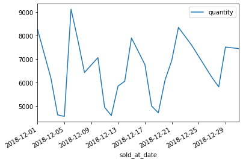

```python
fig = plt.figure();
ts = christmas_2018.ts
ts = ts.groupby('sold_at_date').agg({'quantity': 'sum'})
ts = ts.reset_index()
ts = ts[ts['quantity'] > threshold]
ts = ts.set_index('sold_at_date')
ts.plot()
```

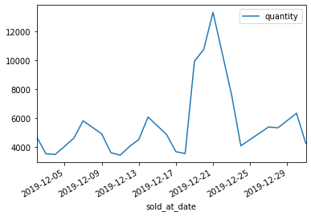

```python
plt.figure();
ts = christmas_2019.ts
ts = ts.groupby('sold_at_date').agg({'quantity': 'sum'})
ts = ts.reset_index()
ts = ts[ts['quantity'] > threshold]
ts = ts.set_index('sold_at_date')
ts.plot()
```

```python
christmas_2018.before
```

|  | orig_item_nr | pv_flag | sold_at_date | quantity | quantity_base | uplift |
| --- | --- | --- | --- | --- | --- | --- |
| 41 | 200066 | 0 | 2018-12-24 | 7574 | 6050.0 | 1.251901 |
| 20 | 200066 | 0 | 2018-12-22 | 8347 | 6050.0 | 1.379669 |

```python
christmas_2019.before
```

|  | orig_item_nr | pv_flag | sold_at_date | quantity | quantity_base | uplift |
| --- | --- | --- | --- | --- | --- | --- |
| 94 | 200066 | 0 | 2019-12-24 | 4087 | 4045.0 | 1.010383 |
| 91 | 200066 | 0 | 2019-12-23 | 7612 | 4045.0 | 1.881829 |

```python
bars_b = alt.Chart(christmas_old.expl_b).mark_bar().encode(
    x='shap_value:Q',
    y=alt.Y(
        'feature:N',
        sort=alt.EncodingSortField(
            field="shap_value",  # The field to use for the sort
            order="descending"  # The order to sort in
        )
    ),
    color=alt.condition(
        alt.datum.shap_value > 0,
        alt.value("steelblue"),  # The positive color
        alt.value("orange")  # The negative color
    )
)
text_b = bars_b.mark_text(
    align='left',
    baseline='middle',
    dx=3  # Nudges text to right so it doesn't appear on top of the bar
).encode(
    text='shap_value:Q',
       color=alt.condition(
        alt.datum.shap_value > 0,
        alt.value("steelblue"),  # The positive color
        alt.value("red")  # The negative color
    )
)
bars_a = alt.Chart(christmas_old.expl_a).mark_bar().encode(
    x='shap_value:Q',
    y=alt.Y(
        'feature:N',
        sort=alt.EncodingSortField(
            field="shap_value",  # The field to use for the sort
            order="descending"  # The order to sort in
        )
    ),
    color=alt.condition(
        alt.datum.shap_value > 0,
        alt.value("steelblue"),  # The positive color
        alt.value("orange")  # The negative color
    )
)
text_a = bars_a.mark_text(
    align='left',
    baseline='middle',
    dx=3  # Nudges text to right so it doesn't appear on top of the bar
).encode(
    text='shap_value:Q',
       color=alt.condition(
        alt.datum.shap_value > 0,
        alt.value("steelblue"),  # The positive color
        alt.value("red")  # The negative color
    )
)
```

Shapley values for the data before holiday. Old features.

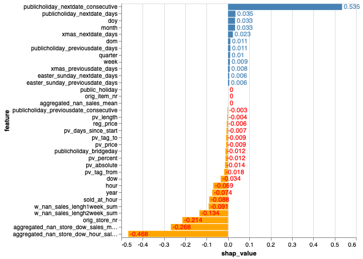

```python
(bars_b + text_b).properties(height=400, width = 400)
```

Shapley values for the data after holiday. Old features. Bridge day feature place an important role here

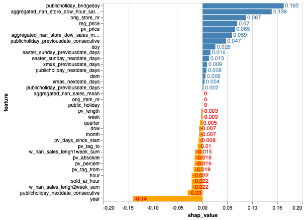

```python
(bars_a + text_a).properties(height=400, width = 400)
```

```python
bars_b = alt.Chart(christmas_new.expl_b).mark_bar().encode(
    x='shap_value:Q',
    y=alt.Y(
        'feature:N',
        sort=alt.EncodingSortField(
            field="shap_value",  # The field to use for the sort
            order="descending"  # The order to sort in
        )
    ),
    color=alt.condition(
        alt.datum.shap_value > 0,
        alt.value("steelblue"),  # The positive color
        alt.value("orange")  # The negative color
    )
)
text_b = bars_b.mark_text(
    align='left',
    baseline='middle',
    dx=3  # Nudges text to right so it doesn't appear on top of the bar
).encode(
    text='shap_value:Q',
       color=alt.condition(
        alt.datum.shap_value > 0,
        alt.value("steelblue"),  # The positive color
        alt.value("red")  # The negative color
    )
)
bars_a = alt.Chart(christmas_new.expl_a).mark_bar().encode(
    x='shap_value:Q',
    y=alt.Y(
        'feature:N',
        sort=alt.EncodingSortField(
            field="shap_value",  # The field to use for the sort
            order="descending"  # The order to sort in
        )
    ),
    color=alt.condition(
        alt.datum.shap_value > 0,
        alt.value("steelblue"),  # The positive color
        alt.value("orange")  # The negative color
    )
)
text_a = bars_a.mark_text(
    align='left',
    baseline='middle',
    dx=3  # Nudges text to right so it doesn't appear on top of the bar
).encode(
    text='shap_value:Q',
       color=alt.condition(
        alt.datum.shap_value > 0,
        alt.value("steelblue"),  # The positive color
        alt.value("red")  # The negative color
    )
)
```

Shapley values for the data before holiday. New features.

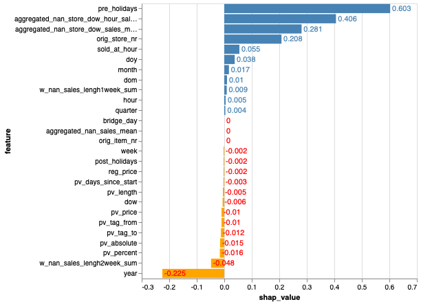

```python
(bars_b + text_b).properties(height=400, width = 400)
```

Shapley values for the data after holiday. New features.

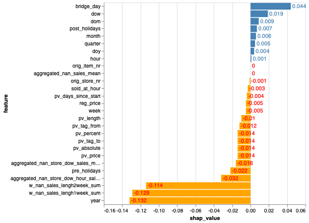

```python
(bars_a + text_a).properties(height=400, width = 400)
```

RMSE of the baseline

```python
print(christmas_base.rmse)
```

```
2.0314188402803666
```

RMSE of the baseline + original public holiday features

```python
print(christmas_old.rmse)
```

```
2.0352748693007925
```

RMSE of the baseline + new public holiday features

```python
print(christmas_new.rmse)
```

```
2.020773486106339
```

```python
import matplotlib.pyplot as plt
```

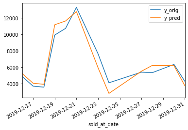

```python
plt.figure();
christmas_base.predictions[christmas_base.predictions['y_orig'] > threshold].plot()
```

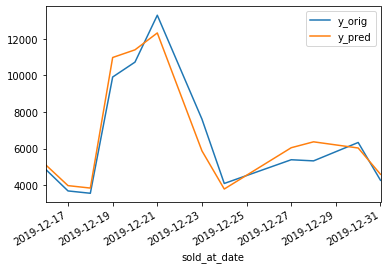

```python
plt.figure();
christmas_old.predictions[christmas_old.predictions['y_orig'] > threshold].plot()
```

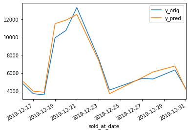

```python
plt.figure();
christmas_new.predictions[christmas_new.predictions['y_orig'] > threshold].plot()
```

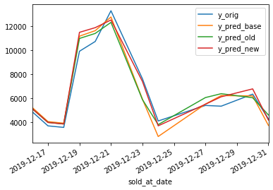

```python
df1 = christmas_base.predictions[christmas_base.predictions['y_orig'] > threshold]
df2 = christmas_old.predictions[christmas_old.predictions['y_orig'] > threshold]
df3 = christmas_new.predictions[christmas_new.predictions['y_orig'] > threshold]

df12 = pd.merge(df1.rename(columns={'y_pred': 'y_pred_base'}),
                df2.rename(columns={'y_pred': 'y_pred_old'})[['y_pred_old']],
         on='sold_at_date', how='inner')

pd.merge(df12, df3.rename(columns={'y_pred': 'y_pred_new'})[['y_pred_new']],
         on='sold_at_date', how='inner').plot()
```

# Analysis of Easter

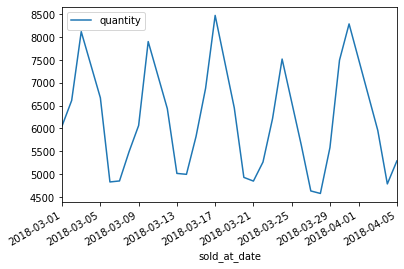

```python
plt.figure();
ts = easter_2018.ts
ts = ts.groupby('sold_at_date').agg({'quantity': 'sum'})
ts = ts.reset_index()
ts = ts[ts['quantity'] > threshold]
ts = ts.set_index('sold_at_date')
ts.plot()
```

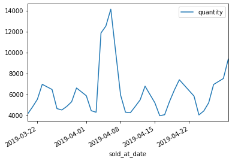

```python
plt.figure();
ts = easter_2019.ts
ts = ts.groupby('sold_at_date').agg({'quantity': 'sum'})
ts = ts.reset_index()
ts = ts[ts['quantity'] > threshold]
ts = ts.set_index('sold_at_date')
ts.plot()
```

```python
easter_2018.before
```

|  | orig_item_nr | pv_flag | sold_at_date | quantity | quantity_base | uplift |
| --- | --- | --- | --- | --- | --- | --- |
| 64 | 200066 | 0 | 2018-03-30 | 7494 | 5821.0 | 1.287408 |
| 43 | 200066 | 0 | 2018-03-31 | 8288 | 5821.0 | 1.423810 |

```python
easter_2019.before
```

|  | orig_item_nr | pv_flag | sold_at_date | quantity | quantity_base | uplift |
| --- | --- | --- | --- | --- | --- | --- |
| 23 | 200066 | 0 | 2019-04-19 | 6416 | 4812.5 | 1.333195 |
| 31 | 200066 | 0 | 2019-04-20 | 7392 | 4812.5 | 1.536000 |

```python
bars_b = alt.Chart(easter_old.expl_b).mark_bar().encode(
    x='shap_value:Q',
    y=alt.Y(
        'feature:N',
        sort=alt.EncodingSortField(
            field="shap_value",  # The field to use for the sort
            order="descending"  # The order to sort in
        )
    ),
    color=alt.condition(
        alt.datum.shap_value > 0,
        alt.value("steelblue"),  # The positive color
        alt.value("orange")  # The negative color
    )
)
text_b = bars_b.mark_text(
    align='left',
    baseline='middle',
    dx=3  # Nudges text to right so it doesn't appear on top of the bar
).encode(
    text='shap_value:Q',
       color=alt.condition(
        alt.datum.shap_value > 0,
        alt.value("steelblue"),  # The positive color
        alt.value("red")  # The negative color
    )
)
bars_a = alt.Chart(easter_old.expl_a).mark_bar().encode(
    x='shap_value:Q',
    y=alt.Y(
        'feature:N',
        sort=alt.EncodingSortField(
            field="shap_value",  # The field to use for the sort
            order="descending"  # The order to sort in
        )
    ),
    color=alt.condition(
        alt.datum.shap_value > 0,
        alt.value("steelblue"),  # The positive color
        alt.value("orange")  # The negative color
    )
)
text_a = bars_a.mark_text(
    align='left',
    baseline='middle',
    dx=3  # Nudges text to right so it doesn't appear on top of the bar
).encode(
    text='shap_value:Q',
       color=alt.condition(
        alt.datum.shap_value > 0,
        alt.value("steelblue"),  # The positive color
        alt.value("red")  # The negative color
    )
)
```

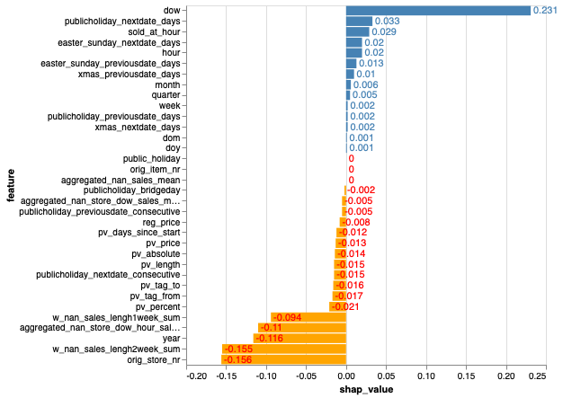

```python
(bars_b + text_b).properties(height=400, width = 400)
```

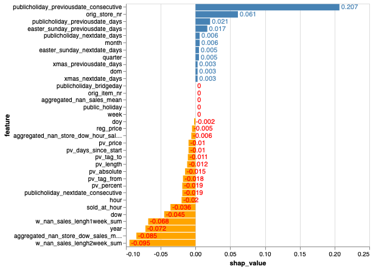

```python
(bars_a + text_a).properties(height=400, width = 400)
```

```python
bars_b = alt.Chart(easter_new.expl_b).mark_bar().encode(
    x='shap_value:Q',
    y=alt.Y(
        'feature:N',
        sort=alt.EncodingSortField(
            field="shap_value",  # The field to use for the sort
            order="descending"  # The order to sort in
        )
    ),
    color=alt.condition(
        alt.datum.shap_value > 0,
        alt.value("steelblue"),  # The positive color
        alt.value("orange")  # The negative color
    )
)
text_b = bars_b.mark_text(
    align='left',
    baseline='middle',
    dx=3  # Nudges text to right so it doesn't appear on top of the bar
).encode(
    text='shap_value:Q',
       color=alt.condition(
        alt.datum.shap_value > 0,
        alt.value("steelblue"),  # The positive color
        alt.value("red")  # The negative color
    )
)
bars_a = alt.Chart(easter_new.expl_a).mark_bar().encode(
    x='shap_value:Q',
    y=alt.Y(
        'feature:N',
        sort=alt.EncodingSortField(
            field="shap_value",  # The field to use for the sort
            order="descending"  # The order to sort in
        )
    ),
    color=alt.condition(
        alt.datum.shap_value > 0,
        alt.value("steelblue"),  # The positive color
        alt.value("orange")  # The negative color
    )
)
text_a = bars_a.mark_text(
    align='left',
    baseline='middle',
    dx=3  # Nudges text to right so it doesn't appear on top of the bar
).encode(
    text='shap_value:Q',
       color=alt.condition(
        alt.datum.shap_value > 0,
        alt.value("steelblue"),  # The positive color
        alt.value("red")  # The negative color
    )
)
```

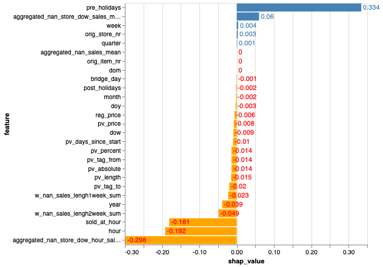

```python
(bars_b + text_b).properties(height=400, width = 400)
```

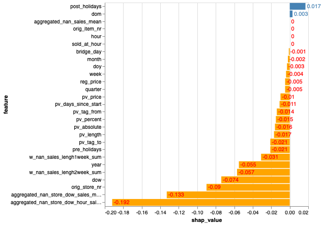

```python
(bars_a + text_a).properties(height=400, width = 400)
```

```python
print(easter_base.rmse)
```

```
1.5540074105397426
```

```python
print(easter_old.rmse)
```

```
1.5434873979737176
```

```python
print(easter_new.rmse)
```

```
1.5436306802463224
```

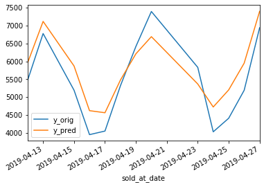

```python
plt.figure();
easter_base.predictions[easter_base.predictions['y_orig'] > threshold].plot()
```

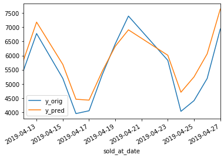

```python
plt.figure();
easter_old.predictions[easter_old.predictions['y_orig'] > threshold].plot()
```

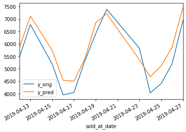

```python
plt.figure();
easter_new.predictions[easter_new.predictions['y_orig'] > threshold].plot()
```

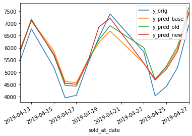

```python
df1 = easter_base.predictions[easter_base.predictions['y_orig'] > threshold]
df2 = easter_old.predictions[easter_old.predictions['y_orig'] > threshold]
df3 = easter_new.predictions[easter_new.predictions['y_orig'] > threshold]

df12 = pd.merge(df1.rename(columns={'y_pred': 'y_pred_base'}),
                df2.rename(columns={'y_pred': 'y_pred_old'})[['y_pred_old']],
         on='sold_at_date', how='inner')

pd.merge(df12, df3.rename(columns={'y_pred': 'y_pred_new'})[['y_pred_new']],
         on='sold_at_date', how='inner').plot()
```

# Analysis of Christy Himmelfahrt

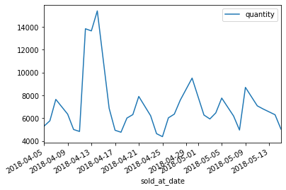

```python
plt.figure();
ts = himmel_fahrt_2018.ts
ts = ts.groupby('sold_at_date').agg({'quantity': 'sum'})
ts = ts.reset_index()
ts = ts[ts['quantity'] > threshold]
ts = ts.set_index('sold_at_date')
ts.plot()
```

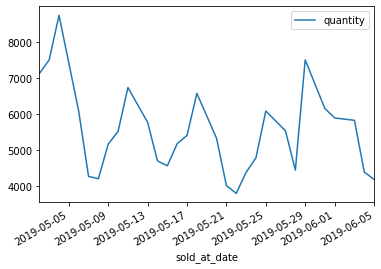

```python
plt.figure();
ts = himmel_fahrt_2019.ts
ts = ts.groupby('sold_at_date').agg({'quantity': 'sum'})
ts = ts.reset_index()
ts = ts[ts['quantity'] > threshold]
ts = ts.set_index('sold_at_date')
ts.plot()
```

```python
himmel_fahrt_2018.before
```

|  | orig_item_nr | pv_flag | sold_at_date | quantity | quantity_base | uplift |
| --- | --- | --- | --- | --- | --- | --- |
| 73 | 200066 | 0 | 2018-05-08 | 4953 | 5844.5 | 0.847463 |
| 83 | 200066 | 0 | 2018-05-09 | 8690 | 5844.5 | 1.486868 |

```python
himmel_fahrt_2019.before
```

|  | orig_item_nr | pv_flag | sold_at_date | quantity | quantity_base | uplift |
| --- | --- | --- | --- | --- | --- | --- |
| 14 | 200066 | 0 | 2019-05-28 | 4437 | 4735.5 | 0.936965 |
| 1 | 200066 | 0 | 2019-05-29 | 7499 | 4735.5 | 1.583571 |

```python
bars_b = alt.Chart(himmel_fahrt_old.expl_b).mark_bar().encode(
    x='shap_value:Q',
    y=alt.Y(
        'feature:N',
        sort=alt.EncodingSortField(
            field="shap_value",  # The field to use for the sort
            order="descending"  # The order to sort in
        )
    ),
    color=alt.condition(
        alt.datum.shap_value > 0,
        alt.value("steelblue"),  # The positive color
        alt.value("orange")  # The negative color
    )
)
text_b = bars_b.mark_text(
    align='left',
    baseline='middle',
    dx=3  # Nudges text to right so it doesn't appear on top of the bar
).encode(
    text='shap_value:Q',
       color=alt.condition(
        alt.datum.shap_value > 0,
        alt.value("steelblue"),  # The positive color
        alt.value("red")  # The negative color
    )
)
bars_a = alt.Chart(himmel_fahrt_old.expl_a).mark_bar().encode(
    x='shap_value:Q',
    y=alt.Y(
        'feature:N',
        sort=alt.EncodingSortField(
            field="shap_value",  # The field to use for the sort
            order="descending"  # The order to sort in
        )
    ),
    color=alt.condition(
        alt.datum.shap_value > 0,
        alt.value("steelblue"),  # The positive color
        alt.value("orange")  # The negative color
    )
)
text_a = bars_a.mark_text(
    align='left',
    baseline='middle',
    dx=3  # Nudges text to right so it doesn't appear on top of the bar
).encode(
    text='shap_value:Q',
       color=alt.condition(
        alt.datum.shap_value > 0,
        alt.value("steelblue"),  # The positive color
        alt.value("red")  # The negative color
    )
)
```

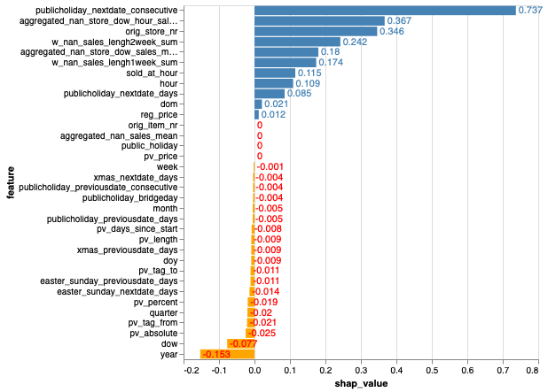

```python
(bars_b + text_b).properties(height=400, width = 400)
```

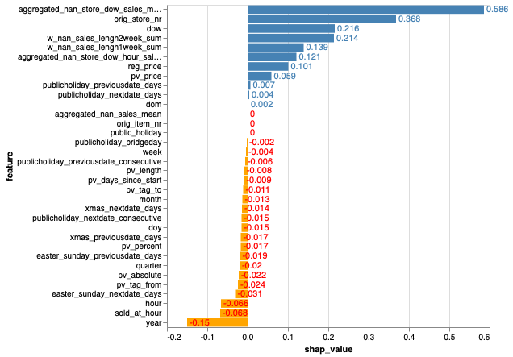

```python
(bars_a + text_a).properties(height=400, width = 400)
```

```python
bars_b = alt.Chart(himmel_fahrt_new.expl_b).mark_bar().encode(
    x='shap_value:Q',
    y=alt.Y(
        'feature:N',
        sort=alt.EncodingSortField(
            field="shap_value",  # The field to use for the sort
            order="descending"  # The order to sort in
        )
    ),
    color=alt.condition(
        alt.datum.shap_value > 0,
        alt.value("steelblue"),  # The positive color
        alt.value("orange")  # The negative color
    )
)
text_b = bars_b.mark_text(
    align='left',
    baseline='middle',
    dx=3  # Nudges text to right so it doesn't appear on top of the bar
).encode(
    text='shap_value:Q',
       color=alt.condition(
        alt.datum.shap_value > 0,
        alt.value("steelblue"),  # The positive color
        alt.value("red")  # The negative color
    )
)
bars_a = alt.Chart(himmel_fahrt_new.expl_a).mark_bar().encode(
    x='shap_value:Q',
    y=alt.Y(
        'feature:N',
        sort=alt.EncodingSortField(
            field="shap_value",  # The field to use for the sort
            order="descending"  # The order to sort in
        )
    ),
    color=alt.condition(
        alt.datum.shap_value > 0,
        alt.value("steelblue"),  # The positive color
        alt.value("orange")  # The negative color
    )
)
text_a = bars_a.mark_text(
    align='left',
    baseline='middle',
    dx=3  # Nudges text to right so it doesn't appear on top of the bar
).encode(
    text='shap_value:Q',
       color=alt.condition(
        alt.datum.shap_value > 0,
        alt.value("steelblue"),  # The positive color
        alt.value("red")  # The negative color
    )
)
```

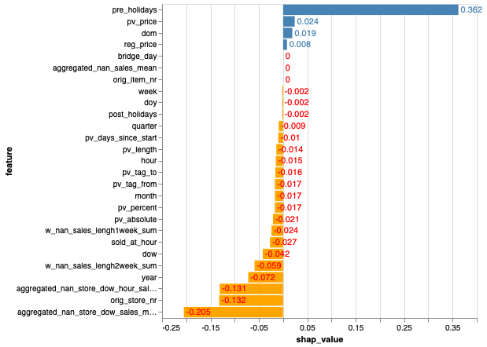

```python
(bars_b + text_b).properties(height=400, width = 400)
```

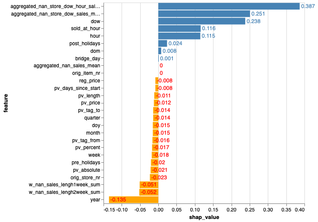

```python
(bars_a + text_a).properties(height=400, width = 400)
```

```python
print(himmel_fahrt_base.rmse)
```

```
1.4973744198485228
```

```python
print(himmel_fahrt_old.rmse)
```

```
1.466991287641274
```

```python
print(himmel_fahrt_new.rmse)
```

```
1.49383930849821
```

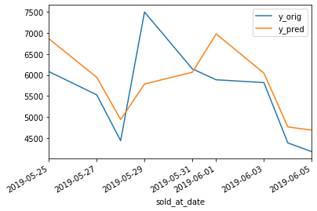

```python
plt.figure();
himmel_fahrt_base.predictions[himmel_fahrt_base.predictions['y_orig'] > threshold].plot()
```

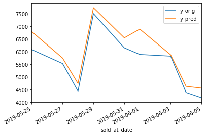

```python
plt.figure();
himmel_fahrt_old.predictions[himmel_fahrt_old.predictions['y_orig'] > threshold].plot()
```

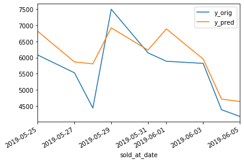

```python
plt.figure();
himmel_fahrt_new.predictions[himmel_fahrt_new.predictions['y_orig'] > threshold].plot()
```

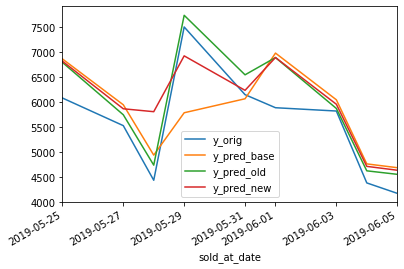

```python
df1 = himmel_fahrt_base.predictions[himmel_fahrt_base.predictions['y_orig'] > threshold]
df2 = himmel_fahrt_old.predictions[himmel_fahrt_old.predictions['y_orig'] > threshold]
df3 = himmel_fahrt_new.predictions[himmel_fahrt_new.predictions['y_orig'] > threshold]

df12 = pd.merge(df1.rename(columns={'y_pred': 'y_pred_base'}),
                df2.rename(columns={'y_pred': 'y_pred_old'})[['y_pred_old']],
         on='sold_at_date', how='inner')

pd.merge(df12, df3.rename(columns={'y_pred': 'y_pred_new'})[['y_pred_new']],
         on='sold_at_date', how='inner').plot()
```